# Goalcast Content Consumption Data Analysis

```python
import warnings
warnings.filterwarnings('ignore') # to get rid of warning messages
import datetime
from datetime import datetime
import calendar
import pandas as pd
import numpy as np
import numpy as np
from sklearn import linear_model
import matplotlib.pyplot as plt
import seaborn as sns
```

### Exploring the data

```python
#loading the datacolumns which at least has one value
df = pd.read_csv('Live.csv' )
df = df.dropna(axis=1, how = 'all')
df.head()
```

|  | status_id | status_type | status_published | num_reactions | num_comments | num_shares | num_likes | num_loves | num_wows | num_hahas | num_sads | num_angrys |
| --- | --- | --- | --- | --- | --- | --- | --- | --- | --- | --- | --- | --- |
| 0 | 246675545449582_1649696485147474 | video | 4/22/2018 6:00 | 529 | 512 | 262 | 432 | 92 | 3 | 1 | 1 | 0 |
| 1 | 246675545449582_1649426988507757 | photo | 4/21/2018 22:45 | 150 | 0 | 0 | 150 | 0 | 0 | 0 | 0 | 0 |
| 2 | 246675545449582_1648730588577397 | video | 4/21/2018 6:17 | 227 | 236 | 57 | 204 | 21 | 1 | 1 | 0 | 0 |
| 3 | 246675545449582_1648576705259452 | photo | 4/21/2018 2:29 | 111 | 0 | 0 | 111 | 0 | 0 | 0 | 0 | 0 |
| 4 | 246675545449582_1645700502213739 | photo | 4/18/2018 3:22 | 213 | 0 | 0 | 204 | 9 | 0 | 0 | 0 | 0 |

```python
df.info()
```

```
<class 'pandas.core.frame.DataFrame'>
RangeIndex: 7050 entries, 0 to 7049
Data columns (total 12 columns):
 #   Column            Non-Null Count  Dtype
---  ------            --------------  -----
 0   status_id         7050 non-null   object
 1   status_type       7050 non-null   object
 2   status_published  7050 non-null   object
 3   num_reactions     7050 non-null   int64
 4   num_comments      7050 non-null   int64
 5   num_shares        7050 non-null   int64
 6   num_likes         7050 non-null   int64
 7   num_loves         7050 non-null   int64
 8   num_wows          7050 non-null   int64
 9   num_hahas         7050 non-null   int64
 10  num_sads          7050 non-null   int64
 11  num_angrys        7050 non-null   int64
dtypes: int64(9), object(3)
memory usage: 661.1+ KB
```

```python
#Check if there are duplications

duplicateRowsDF = df[df.duplicated()]
#duplicateRowsDF['status_id'].shape
duplicateRowsDF.shape
```

```
(51, 12)
```

```python
#drop 51 duplicates
df.drop_duplicates(inplace=True)
df.shape
```

```
(6999, 12)
```

**Findings**

- We have 7050 datapoints and all the features are available,
- no missing data.
- 51 duplicate observations
- 6999 unique observations to work with

```python
print('Records are distributed by type as follows: ')
df['status_type'].value_counts()
```

```
Records are distributed by type as follows:
```

```
photo     4244
video     2333
status     359
link        63
Name: status_type, dtype: int64
```

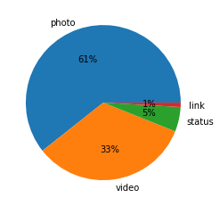

```python
#sns.countplot(df['status_type'])
plt.pie(df['status_type'].value_counts(), labels =df['status_type'].value_counts().index ,  autopct='%.0f%%')
plt.show()
```

**Findings**

- observations categories are distributed as follows
  - photo 4244 %61
  - video 2333 %33
  - status 359 %5
  - link 63 %1

```python
print(sum(df.num_likes+df.num_loves+df.num_wows+df.num_hahas+df.num_sads+df.num_angrys-df.num_reactions))
print(sum(df.num_likes+df.num_loves+df.num_wows+df.num_hahas+df.num_sads+df.num_angrys==df.num_reactions))
print(sum(df.num_reactions))
```

```
-19
6990
1574737
```

**Findings**

- although num_reactions sounds like the total summition of all (likes, lols, waws etc...) we have a few exception, 6999-6990=9 records which are not, total difference is 19 out of around 1.5 M, can be ignored

I will split the features that we have into:

- Interactions: (reactions, comments and shares)
- Reactions: likes, loves, wows, hahas, sads and angrys

```python
corr = df[['num_reactions','num_comments','num_shares']].corr()

corr.style.background_gradient()
```

|  | num_reactions | num_comments | num_shares |
| --- | --- | --- | --- |
| num_reactions | 1.000000 | 0.156190 | 0.259640 |
| num_comments | 0.156190 | 1.000000 | 0.640536 |
| num_shares | 0.259640 | 0.640536 | 1.000000 |

**Findings**

- Interactions: comments and shares are correlated

```python
corr = df[['num_likes','num_loves','num_wows','num_hahas','num_sads','num_angrys']].corr()
corr.style.background_gradient()
```

|  | num_likes | num_loves | num_wows | num_hahas | num_sads | num_angrys |
| --- | --- | --- | --- | --- | --- | --- |
| num_likes | 1.000000 | 0.212715 | 0.200015 | 0.123129 | 0.057110 | 0.096276 |
| num_loves | 0.212715 | 1.000000 | 0.510148 | 0.507899 | 0.226574 | 0.394818 |
| num_wows | 0.200015 | 0.510148 | 1.000000 | 0.288468 | 0.091425 | 0.191672 |
| num_hahas | 0.123129 | 0.507899 | 0.288468 | 1.000000 | 0.154035 | 0.225083 |
| num_sads | 0.057110 | 0.226574 | 0.091425 | 0.154035 | 1.000000 | 0.143711 |
| num_angrys | 0.096276 | 0.394818 | 0.191672 | 0.225083 | 0.143711 | 1.000000 |

**Findings**

- High correlation between loves, waws and hahas
- Medium correlation between loves and angrys

```python
corr = df[['num_likes','num_loves','num_wows','num_hahas','num_sads','num_angrys','num_comments','num_shares']].corr()
corr.style.background_gradient()
```

|  | num_likes | num_loves | num_wows | num_hahas | num_sads | num_angrys | num_comments | num_shares |
| --- | --- | --- | --- | --- | --- | --- | --- | --- |
| num_likes | 1.000000 | 0.212715 | 0.200015 | 0.123129 | 0.057110 | 0.096276 | 0.105934 | 0.179664 |
| num_loves | 0.212715 | 1.000000 | 0.510148 | 0.507899 | 0.226574 | 0.394818 | 0.521320 | 0.820284 |
| num_wows | 0.200015 | 0.510148 | 1.000000 | 0.288468 | 0.091425 | 0.191672 | 0.163506 | 0.409803 |
| num_hahas | 0.123129 | 0.507899 | 0.288468 | 1.000000 | 0.154035 | 0.225083 | 0.325064 | 0.399864 |
| num_sads | 0.057110 | 0.226574 | 0.091425 | 0.154035 | 1.000000 | 0.143711 | 0.257545 | 0.218628 |
| num_angrys | 0.096276 | 0.394818 | 0.191672 | 0.225083 | 0.143711 | 1.000000 | 0.239557 | 0.332355 |
| num_comments | 0.105934 | 0.521320 | 0.163506 | 0.325064 | 0.257545 | 0.239557 | 1.000000 | 0.640536 |
| num_shares | 0.179664 | 0.820284 | 0.409803 | 0.399864 | 0.218628 | 0.332355 | 0.640536 | 1.000000 |

**Findings**

• Looking at the correlation between the different emotions and (num_comments, num_shares) we find that the highest correlation is between shares and (loves, then wows and hahas)

| status_type | num_reactions | num_comments | num_shares |
| --- | --- | --- | --- |
| link | 23319 | 359 | 277 |
| photo | 731372 | 65678 | 10574 |
| status | 158944 | 13078 | 925 |
| video | 661102 | 1499524 | 269994 |

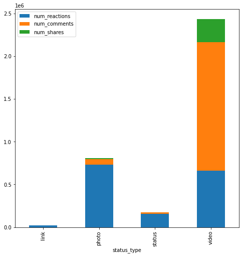

```python
df.groupby('status_type').sum().plot(kind='bar' , stacked = True ,
                                      y=['num_reactions','num_comments','num_shares'] , figsize=(8,8))
df[['status_type','num_reactions','num_comments','num_shares']].groupby('status_type').sum()
```

**Findings**

- Videos harvest the highest number of interactions, then photos, status and the smallest number of interactions goes to links
- Among the interactions, comments is the dominant type then comes the reactions

| year | status_type | num_likes | num_loves | num_wows | num_hahas | num_sads | num_angrys |
| --- | --- | --- | --- | --- | --- | --- | --- |
| 2012 | photo | 12389 | 0 | 0 | 0 | 0 | 0 |
| 2013 | photo | 23015 | 0 | 0 | 0 | 0 | 0 |
|  | status | 71 | 0 | 0 | 0 | 0 | 0 |
|  | video | 22438 | 0 | 0 | 0 | 0 | 0 |
| 2014 | link | 37 | 0 | 0 | 0 | 0 | 0 |
|  | photo | 3480 | 0 | 0 | 0 | 0 | 0 |
|  | video | 138114 | 0 | 0 | 0 | 0 | 0 |
| 2015 | link | 20749 | 0 | 0 | 0 | 0 | 0 |
|  | photo | 316681 | 0 | 0 | 0 | 0 | 0 |
|  | status | 103192 | 0 | 0 | 0 | 0 | 0 |
|  | video | 78417 | 0 | 0 | 0 | 0 | 0 |
| 2016 | link | 907 | 9 | 8 | 1 | 0 | 0 |
|  | photo | 78309 | 1034 | 298 | 61 | 272 | 1 |
|  | status | 4861 | 32 | 9 | 10 | 13 | 0 |
|  | video | 17424 | 1728 | 109 | 78 | 44 | 12 |
| 2017 | link | 1212 | 9 | 2 | 0 | 0 | 0 |
|  | photo | 119390 | 2390 | 915 | 203 | 135 | 79 |
|  | status | 11692 | 191 | 48 | 16 | 55 | 6 |
|  | video | 95323 | 24907 | 767 | 1287 | 456 | 178 |
| 2018 | link | 381 | 1 | 2 | 1 | 0 | 0 |
|  | photo | 168226 | 2324 | 1410 | 529 | 129 | 89 |
|  | status | 37981 | 326 | 366 | 14 | 58 | 3 |
|  | video | 215128 | 56297 | 4835 | 2685 | 466 | 403 |

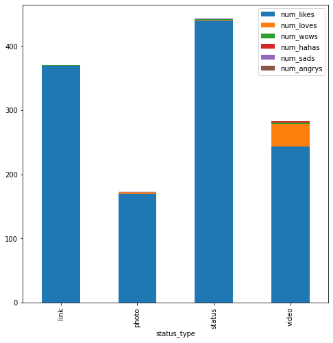

```python
df['status_published_date'] = pd.to_datetime(df['status_published'])
df['year'] = pd.DatetimeIndex(df['status_published_date']).year
df.groupby('status_type').mean().plot(kind='bar' ,
                                      stacked = True ,
                                      y=['num_likes','num_loves','num_wows','num_hahas','num_sads','num_angrys'],
                                      figsize=(8,8))

df[['year','status_type','num_likes','num_loves','num_wows','num_hahas','num_sads','num_angrys']].groupby(['year','status_type']).sum()
```

**Reactions**

**Features Engineering**

Now that I know the published data, I have layed the follwoing points to proceed my exploration

Are the interactions (Reactions, comments and shares) follow any certain pattern related to the a. Weekday, month of the year, year itself b. the hour of hte day when the post is published c. age of the post, will older posts get more interactions?

Out of the publishing date, i will extract the Year, Month, Day, Weekday and Hour to see if the reactions, comments and shares are correlated with these time elements.

```python
df['status_published_date'] = pd.to_datetime(df['status_published'])

print(df.status_type.count() , ' records of data collected between ' , df.status_published_date.max() , df.status_published_date.min())
```

```
6999  records of data collected between  2018-06-13 01:12:00 2012-07-15 02:51:00
```

```python
#creating new features out of the date of
df['year'] = pd.DatetimeIndex(df['status_published_date']).year
df['month'] = pd.DatetimeIndex(df['status_published_date']).month
df['day'] = pd.DatetimeIndex(df['status_published_date']).day
df['wday'] = pd.DatetimeIndex(df['status_published_date']).weekday
df['hour'] = pd.DatetimeIndex(df['status_published_date']).hour
df['age'] = (datetime.now()- df['status_published_date']).astype('<m8[D]')  #age by day
df['all_interactions'] = df['num_reactions']+ df['num_comments'] + df['num_shares']
df.head()
```

|  | status_id | status_type | status_published | num_reactions | num_comments | num_shares | num_likes | num_loves | num_wows | num_hahas | num_sads | num_angrys | status_published_date | year | month | day | wday | hour | age | all_interactions |
| --- | --- | --- | --- | --- | --- | --- | --- | --- | --- | --- | --- | --- | --- | --- | --- | --- | --- | --- | --- | --- |
| 0 | 246675545449582_1649696485147474 | video | 4/22/2018 6:00 | 529 | 512 | 262 | 432 | 92 | 3 | 1 | 1 | 0 | 2018-04-22 06:00:00 | 2018 | 4 | 22 | 6 | 6 | 1281.0 | 1303 |
| 1 | 246675545449582_1649426988507757 | photo | 4/21/2018 22:45 | 150 | 0 | 0 | 150 | 0 | 0 | 0 | 0 | 0 | 2018-04-21 22:45:00 | 2018 | 4 | 21 | 5 | 22 | 1281.0 | 150 |
| 2 | 246675545449582_1648730588577397 | video | 4/21/2018 6:17 | 227 | 236 | 57 | 204 | 21 | 1 | 1 | 0 | 0 | 2018-04-21 06:17:00 | 2018 | 4 | 21 | 5 | 6 | 1282.0 | 520 |
| 3 | 246675545449582_1648576705259452 | photo | 4/21/2018 2:29 | 111 | 0 | 0 | 111 | 0 | 0 | 0 | 0 | 0 | 2018-04-21 02:29:00 | 2018 | 4 | 21 | 5 | 2 | 1282.0 | 111 |
| 4 | 246675545449582_1645700502213739 | photo | 4/18/2018 3:22 | 213 | 0 | 0 | 204 | 9 | 0 | 0 | 0 | 0 | 2018-04-18 03:22:00 | 2018 | 4 | 18 | 2 | 3 | 1285.0 | 213 |

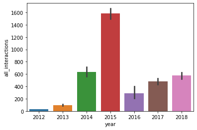

```python
sns.barplot (data=df , y='all_interactions',x='year')
```

From the bar chart above, it is clear that there was an exponential groweth in the average interactions, which reflects the engagements, the average engaement drops in 2016 (the year where emotions other than like were added) that's when the server might have a revamp

| year | all_interactions |
| --- | --- |
| 2012 | 16552 |
| 2013 | 49055 |
| 2014 | 147095 |
| 2015 | 533334 |
| 2016 | 170390 |
| 2017 | 1081592 |
| 2018 | 1437128 |

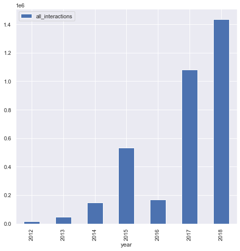

```python
df.groupby('year').sum()[['all_interactions']].plot(kind='bar' ,
                                      stacked = True ,
                                      y=['all_interactions'],
                                      figsize=(8,8))
df.groupby('year').sum()[['all_interactions']]
```

```python
def showPivot(row,col,val='all_interactions', agg='sum'):
    sns.set(rc={'figure.figsize':(20,8.27)})
    x = df[[ row,col,val]].pivot_table(index=row,columns=col, aggfunc=agg)

    sns.heatmap(x)
    x = pd.DataFrame(x)

    print(x.round())
```

```
      all_interactions
year              2012     2013     2014     2015     2016      2017      2018
month
1                  NaN   2902.0  14338.0  54776.0   9909.0   17675.0  191539.0
2                  NaN   2694.0  15990.0  32372.0   7024.0    9073.0  115695.0
3                  NaN   2303.0  50795.0  30332.0  11900.0   17894.0  209423.0
4                  NaN   2570.0  16104.0  48635.0  17959.0    9766.0  247435.0
5                  NaN   1458.0  12320.0  52055.0   9387.0    4050.0  480958.0
6                  NaN   1684.0  10235.0  74062.0   5473.0    8777.0  192078.0
7               2269.0   2000.0  15185.0  33253.0   5935.0   59507.0       NaN
8               5437.0    366.0   5248.0  56914.0   6839.0  158204.0       NaN
9               4372.0   1917.0    165.0  48937.0   4836.0  233959.0       NaN
10              3539.0   9564.0   5007.0  65482.0  15184.0  119745.0       NaN
11               927.0  12992.0     56.0  31203.0  25306.0  180283.0       NaN
12                 8.0   8605.0   1652.0   5313.0  50638.0  262659.0       NaN
```

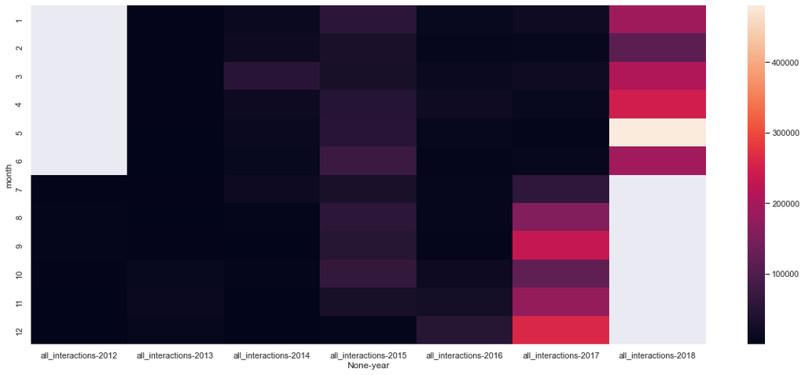

```python
showPivot('month','year')
```

**Findings**

- The heatmap above reflect the increasing number of engagement by month / by year
- the slighltly lighter coler in 2015 reflect the peak happened
- the May 2018 is brighter than June 2018 because we only have data up to 13 June 2018

```
      all_interactions
year              2012   2013    2014    2015    2016    2017   2018
month
1                  NaN   45.0   333.0  1522.0   275.0   465.0  522.0
2                  NaN   49.0   457.0  1349.0   185.0   221.0  362.0
3                  NaN   54.0   977.0  1896.0   183.0   331.0  494.0
4                  NaN   66.0   596.0  2560.0   200.0   264.0  612.0
5                  NaN   54.0   456.0  2169.0   247.0   184.0  828.0
6                  NaN   41.0   569.0  1899.0   274.0   114.0  477.0
7                 28.0   62.0  1380.0  2217.0   165.0   346.0    NaN
8                 27.0   52.0  1050.0  2108.0   180.0   709.0    NaN
9                 25.0   80.0    28.0  1748.0   124.0  1083.0    NaN
10                34.0  162.0   834.0  1336.0   157.0   700.0    NaN
11                31.0  232.0    28.0  1040.0  1100.0   338.0    NaN
12                 3.0  165.0  1652.0   177.0   745.0   393.0    NaN
```

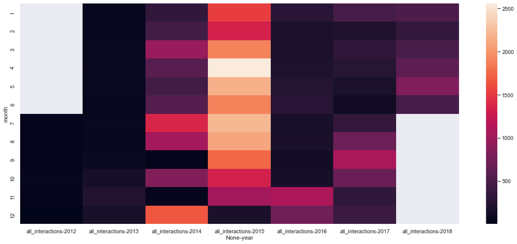

```python
showPivot('month','year','all_interactions','mean')
```

**Findings**

- The average of interactions does not show that posts does not show any tendency to perform better (more interactions) in a certain month

```
     all_interactions
year             2012  2013   2014   2015   2016    2017    2018
wday
0                2692  5297  14583  64223  15424  184661  176403
1                1983  7113  21612  62458  14899  159752  215281
2                2563  9786  13734  84202  39185  161646  191115
3                2012  7229  19024  81551  22379  147285  238618
4                2327  6290  16937  94775  40179  106531  207770
5                2305  8580  31196  63568  18308  182012  213064
6                2670  4760  30009  82557  20016  139705  194877
```

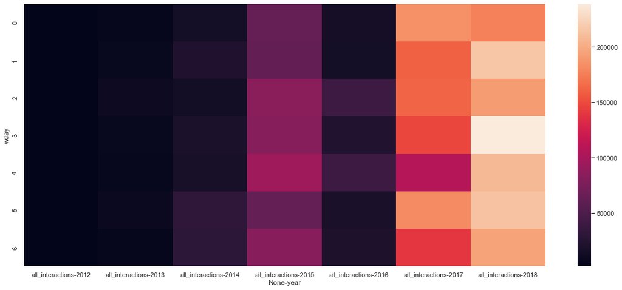

```python
showPivot('wday','year','all_interactions','sum')
```

**Findings**

```
            all_interactions
year                    2012   2013   2014    2015   2016    2017    2018
status_type
link                     NaN    NaN   37.0  1500.0   75.0    77.0    30.0
photo                   28.0   62.0  144.0  1613.0  213.0   124.0   143.0
status                   NaN   64.0    NaN  1343.0  107.0   129.0   434.0
video                    NaN  252.0  693.0  1915.0  649.0  1074.0  1168.0
```

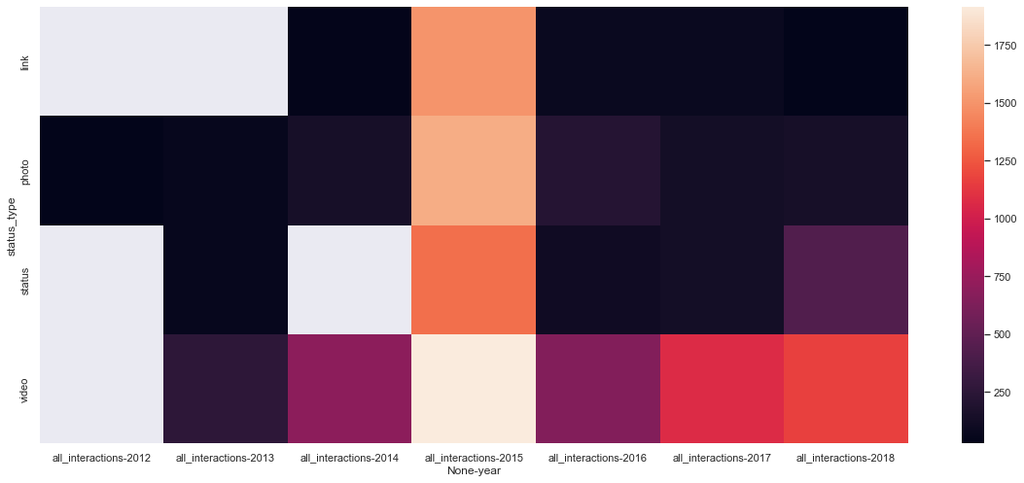

```python
showPivot('status_type','year','all_interactions','mean')
```

**Findings**

- The above shows that videos has always been the most performing post category in term of average interactions

```
            all_interactions                                                  \
year                    2012     2013      2014      2015     2016      2017
status_type
link                     NaN      NaN      37.0   21001.0   1044.0    1385.0
photo                16552.0  25235.0    3599.0  325796.0  85981.0  157691.0
status                   NaN    128.0       NaN  106093.0   5467.0   15737.0
video                    NaN  23692.0  143459.0   80444.0  77898.0  906779.0


year              2018
status_type
link             488.0
photo         192770.0
status         45522.0
video        1198348.0
```

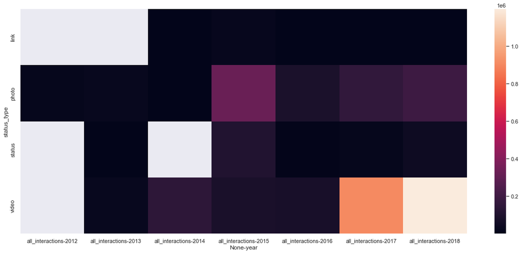

```python
showPivot('status_type','year','all_interactions','sum')
```

**Findings**

### Prediction model regression

I will use a regression model to predict the future engaments:

```python
df
```

|  | status_id | status_type | status_published | num_reactions | num_comments | num_shares | num_likes | num_loves | num_wows | num_hahas | num_sads | num_angrys | status_published_date | year | month | day | wday | hour | age | all_interactions |
| --- | --- | --- | --- | --- | --- | --- | --- | --- | --- | --- | --- | --- | --- | --- | --- | --- | --- | --- | --- | --- |
| 0 | 246675545449582_1649696485147474 | video | 4/22/2018 6:00 | 529 | 512 | 262 | 432 | 92 | 3 | 1 | 1 | 0 | 2018-04-22 06:00:00 | 2018 | 4 | 22 | 6 | 6 | 1281.0 | 1303 |
| 1 | 246675545449582_1649426988507757 | photo | 4/21/2018 22:45 | 150 | 0 | 0 | 150 | 0 | 0 | 0 | 0 | 0 | 2018-04-21 22:45:00 | 2018 | 4 | 21 | 5 | 22 | 1281.0 | 150 |
| 2 | 246675545449582_1648730588577397 | video | 4/21/2018 6:17 | 227 | 236 | 57 | 204 | 21 | 1 | 1 | 0 | 0 | 2018-04-21 06:17:00 | 2018 | 4 | 21 | 5 | 6 | 1282.0 | 520 |
| 3 | 246675545449582_1648576705259452 | photo | 4/21/2018 2:29 | 111 | 0 | 0 | 111 | 0 | 0 | 0 | 0 | 0 | 2018-04-21 02:29:00 | 2018 | 4 | 21 | 5 | 2 | 1282.0 | 111 |
| 4 | 246675545449582_1645700502213739 | photo | 4/18/2018 3:22 | 213 | 0 | 0 | 204 | 9 | 0 | 0 | 0 | 0 | 2018-04-18 03:22:00 | 2018 | 4 | 18 | 2 | 3 | 1285.0 | 213 |
| ... | ... | ... | ... | ... | ... | ... | ... | ... | ... | ... | ... | ... | ... | ... | ... | ... | ... | ... | ... | ... |
| 7045 | 1050855161656896_1061863470556065 | photo | 9/24/2016 2:58 | 89 | 0 | 0 | 89 | 0 | 0 | 0 | 0 | 0 | 2016-09-24 02:58:00 | 2016 | 9 | 24 | 5 | 2 | 1856.0 | 89 |
| 7046 | 1050855161656896_1061334757275603 | photo | 9/23/2016 11:19 | 16 | 0 | 0 | 14 | 1 | 0 | 1 | 0 | 0 | 2016-09-23 11:19:00 | 2016 | 9 | 23 | 4 | 11 | 1857.0 | 16 |
| 7047 | 1050855161656896_1060126464063099 | photo | 9/21/2016 23:03 | 2 | 0 | 0 | 1 | 1 | 0 | 0 | 0 | 0 | 2016-09-21 23:03:00 | 2016 | 9 | 21 | 2 | 23 | 1858.0 | 2 |
| 7048 | 1050855161656896_1058663487542730 | photo | 9/20/2016 0:43 | 351 | 12 | 22 | 349 | 2 | 0 | 0 | 0 | 0 | 2016-09-20 00:43:00 | 2016 | 9 | 20 | 1 | 0 | 1860.0 | 385 |
| 7049 | 1050855161656896_1050858841656528 | photo | 9/10/2016 10:30 | 17 | 0 | 0 | 17 | 0 | 0 | 0 | 0 | 0 | 2016-09-10 10:30:00 | 2016 | 9 | 10 | 5 | 10 | 1870.0 | 17 |

6999 rows × 20 columns

```python
from sklearn.linear_model import LinearRegression
df['date'] = df['status_published_date']

def predict(postType,reaction='num_likes'):
    datemask = (df.year >= 2016) ## just to make sure we're consuming the right period of the data
    mask = (df.status_type==postType)
    vdf = df[datemask]
    vdf = vdf[mask]
    vdf = vdf[['status_type','date','all_interactions' , 'year' , reaction]].groupby('date').mean()
    #vdf = vdf[vdf["all_interactions"] < 3000]
    vdf['avg_interactions'] = vdf[reaction]
    #vdf.drop(labels='avg_interactions' , inplace = True, axis=1)
    P = np.percentile(vdf.avg_interactions, [0, 95])
    vdf = vdf[(vdf.avg_interactions > P[0]) & (vdf.avg_interactions < P[1])]
    vdf.sort_index(inplace=True)
    vdf.reset_index(level=0, inplace=True)

    model = LinearRegression().fit(np.array(vdf.index).reshape(-1, 1),vdf.avg_interactions)
    coefficients = [model.coef_[0],model.intercept_]

    print("The linear trend is given for " +reaction + " for " + postType + " by F(t) = " +str(coefficients[0])+"*t + (" +str (coefficients[1])+")")
    print("(t) is number of days of the post starting " , vdf['date'].min().date())
    linear_vdf = model.predict(np.array(vdf.index).reshape(-1, 1))

    plt.plot(vdf.index, vdf.avg_interactions, color = 'navy', label = 'Original Trend')
    plt.xlabel('No of days')
    plt.ylabel(postType + ' Interactions')
    plt.title('Average ' + postType + ' Ineractions')
    plt.plot(vdf.index, linear_vdf, color = 'orange', label = 'Linear Trend')
    plt.legend(loc = 'upper right')
    plt.show()
```

```
The linear trend is given for num_loves for video by F(t) = 0.01813964916344691*t + (35.54861116864538)
(t) is number of days of the post starting  2016-02-25
```

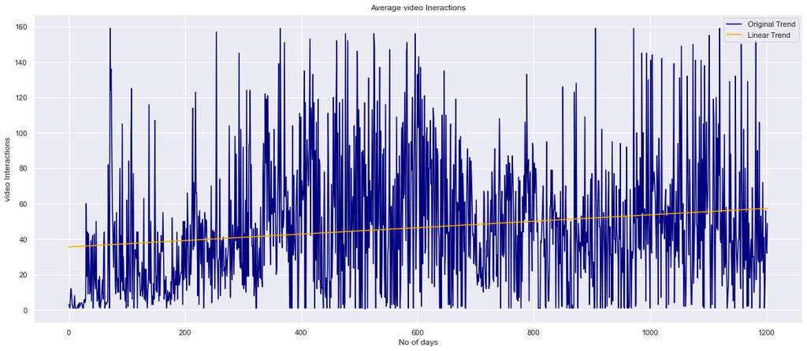

```python
predict('video','num_loves')
```

[output not shown]

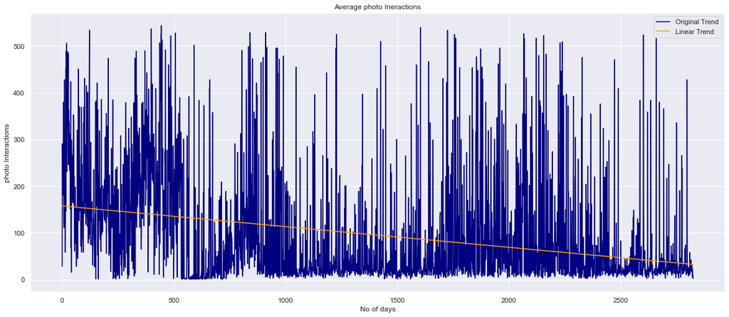

```python
predict('photo')
```

[output not shown]

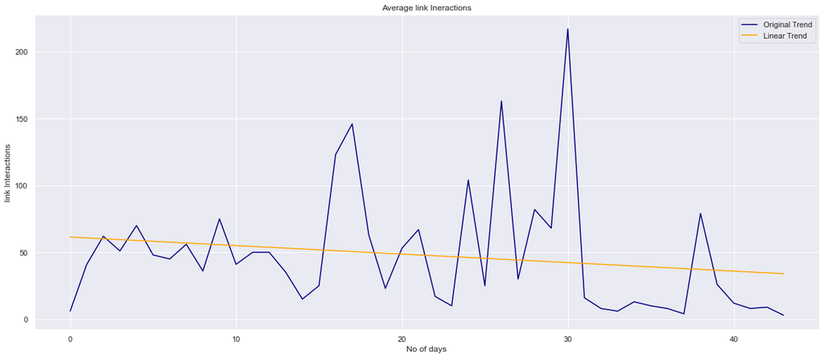

```python
predict('link')
```

[output not shown]

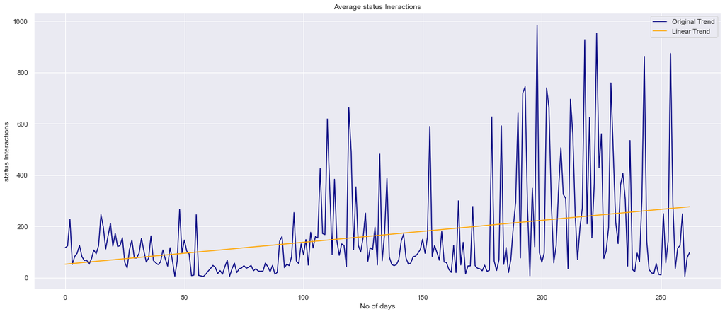

```python
predict('status')
```

### Prediction model using neural network

I will build a NN with the folloiwng inputs (X) 1- Date (day, month, year), weekday and hour of post 2- Number of shares and comments 3- Type of the post

the output will be the number of different interaction type (like, love, lol, etc...) (y)

```python
#preparing the dataframe
X = df[['year','month','day','wday','hour', 'status_type' , 'num_comments','num_shares']]
y= df[['num_likes' , 'num_loves' , 'num_wows'  , 'num_hahas' , 'num_sads'  , 'num_angrys']]

#create dummy features for the status_type (binary)
X = pd.get_dummies(X)
X.shape
```

```
(6999, 11)
```

```python
#Importing losses and optimizers modules
from tensorflow.keras import losses
from tensorflow.keras import optimizers
from sklearn.model_selection import train_test_split
import tensorflow as tf
from tensorflow.keras.models import Sequential
from tensorflow.keras.layers import Dense, Dropout, Activation, BatchNormalization
from tensorflow.keras.utils import to_categorical

#Define the function
def nn_model_1():
    model = Sequential()
    #Add layers as per the architecture mentioned above in the same sequence
    model.add(Dense(64, activation='relu', input_shape=X_train.shape))
    model.add(Dense(128, activation='relu'))
    model.add(Dropout(0.15))
    model.add(Dense(64, activation='relu'))
    model.add(Dense(64, activation='relu'))
    model.add(Dense(32, activation='relu'))
    #model.add(BatchNormalization())
    model.add(Dense(6, activation='softmax'))

    #declare adam optimizer with learning rate of 0.001
    adam = optimizers.Adam(learning_rate=0.001)

    #compile the model
    model.compile(optimizer=adam, loss="categorical_crossentropy", metrics=["accuracy"])

    return model
X_train, X_test, y_train, y_test = train_test_split(X, y, test_size=0.20, random_state=42)
```

```python
# Build the model
model_1 = nn_model_1()



history_model_1 = model_1.fit(X_train , y_train,validation_split=0.3, epochs=20, verbose=1, batch_size = 12)
```

```
WARNING:tensorflow:Model was constructed with shape (None, 5599, 11) for input Tensor("dense_input:0", shape=(None, 5599, 11), dtype=float32), but it was called on an input with incompatible shape (None, 11).
WARNING:tensorflow:Model was constructed with shape (None, 5599, 11) for input Tensor("dense_input:0", shape=(None, 5599, 11), dtype=float32), but it was called on an input with incompatible shape (None, 11).
```

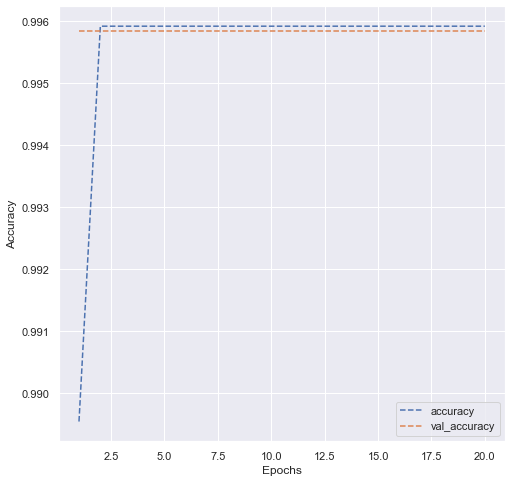

```python
dict_hist = history_model_1.history
list_ep = [i for i in range(1,21)]

plt.figure(figsize = (8,8))
plt.plot(list_ep,dict_hist['accuracy'],ls = '--', label = 'accuracy')
plt.plot(list_ep,dict_hist['val_accuracy'],ls = '--', label = 'val_accuracy')
plt.ylabel('Accuracy')
plt.xlabel('Epochs')
plt.legend()
plt.show()
```

**Findings**

**Imporovement**

- we need to treat the data inbalance (number of observation for the different post types is not the same)
- optimizing and normalizing the input will help getting better prediction
- to help visualizing the percission and recall.